# R Notebook

```r
library(tidyverse)
data(msleep)
library(infer)
library(janitor)
```

# Part 1.1 Hypothesis testing practical

## Question 1: Explore the dataset and familiarise yourself with it.

```r
head(msleep)
```

| name | genus | vore | order | conservation | sleep_total | sleep_rem | sleep_cycle | awake | brainwt | bodywt |
| --- | --- | --- | --- | --- | --- | --- | --- | --- | --- | --- |
| Cheetah | Acinonyx | carni | Carnivora | lc | 12.1 | NA | NA | 11.9 | NA | 50.000 |
| Owl monkey | Aotus | omni | Primates | NA | 17.0 | 1.8 | NA | 7.0 | 0.01550 | 0.480 |
| Mountain beaver | Aplodontia | herbi | Rodentia | nt | 14.4 | 2.4 | NA | 9.6 | NA | 1.350 |
| Greater short-tailed shrew | Blarina | omni | Soricomorpha | lc | 14.9 | 2.3 | 0.1333333 | 9.1 | 0.00029 | 0.019 |
| Cow | Bos | herbi | Artiodactyla | domesticated | 4.0 | 0.7 | 0.6666667 | 20.0 | 0.42300 | 600.000 |
| Three-toed sloth | Bradypus | herbi | Pilosa | NA | 14.4 | 2.2 | 0.7666667 | 9.6 | NA | 3.850 |

```r
names(msleep)
```

```
 [1] "name"         "genus"        "vore"         "order"
 [5] "conservation" "sleep_total"  "sleep_rem"    "sleep_cycle"
 [9] "awake"        "brainwt"      "bodywt"
```

```r
glimpse(msleep)
```

```
Rows: 83
Columns: 11
$ name         <chr> "Cheetah", "Owl monkey", "Mountain beaver", "Greater …
$ genus        <chr> "Acinonyx", "Aotus", "Aplodontia", "Blarina", "Bos", …
$ vore         <chr> "carni", "omni", "herbi", "omni", "herbi", "herbi", "…
$ order        <chr> "Carnivora", "Primates", "Rodentia", "Soricomorpha", …
$ conservation <chr> "lc", NA, "nt", "lc", "domesticated", NA, "vu", NA, "…
$ sleep_total  <dbl> 12.1, 17.0, 14.4, 14.9, 4.0, 14.4, 8.7, 7.0, 10.1, 3.…
$ sleep_rem    <dbl> NA, 1.8, 2.4, 2.3, 0.7, 2.2, 1.4, NA, 2.9, NA, 0.6, 0…
$ sleep_cycle  <dbl> NA, NA, NA, 0.1333333, 0.6666667, 0.7666667, 0.383333…
$ awake        <dbl> 11.9, 7.0, 9.6, 9.1, 20.0, 9.6, 15.3, 17.0, 13.9, 21.…
$ brainwt      <dbl> NA, 0.01550, NA, 0.00029, 0.42300, NA, NA, NA, 0.0700…
$ bodywt       <dbl> 50.000, 0.480, 1.350, 0.019, 600.000, 3.850, 20.490, …
```

## Question 2: Jabberwockies sleep for around 7 hours a night, on average. Perform an appropriate statistical test to determine whether the mean sleep_total in the sampled population of animal types differs from the typical value for jabberwockies.

### Step 1: Generate hypotheses

Compare the mean from our animal sample to 7 i.e. one sample mean

H0: mean_sleep_total for animal sample = 7 H1 mean_sleep_total for animal sample != 7 significance level = 0.05

Generate a bootstrap with replacement for the null distribution and p value to prove/disprove null hypothesis

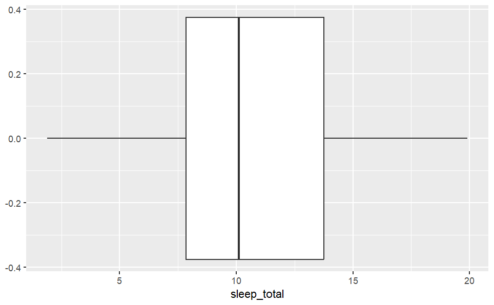

```r
msleep %>%
  ggplot(aes(x = sleep_total))+
  geom_boxplot()
```

Median is around 10, but a wide distribution of sleep length. Already looking like we will be disproving the null hypothesis, due to the position of the interquartile range (8-13ish)

### Step 2:

Calculate test statistic (ie mean sleep_total of the animal sample)

```r
observed_stat <- msleep %>%
  summarise(mean_sleep_total = mean(sleep_total))

observed_stat
```

| mean_sleep_total |
| --- |
| 10.43373 |

### Step 3: Generate null distribution

```r
sleep_null_distribution <- msleep %>%
  specify(response = sleep_total) %>%
  hypothesize(null = "point", mu = 7) %>%
  generate(reps = 10000, type = "bootstrap") %>%
  calculate(stat = "mean")
```

### Step 4: Visualise null distribution with calculated statistic

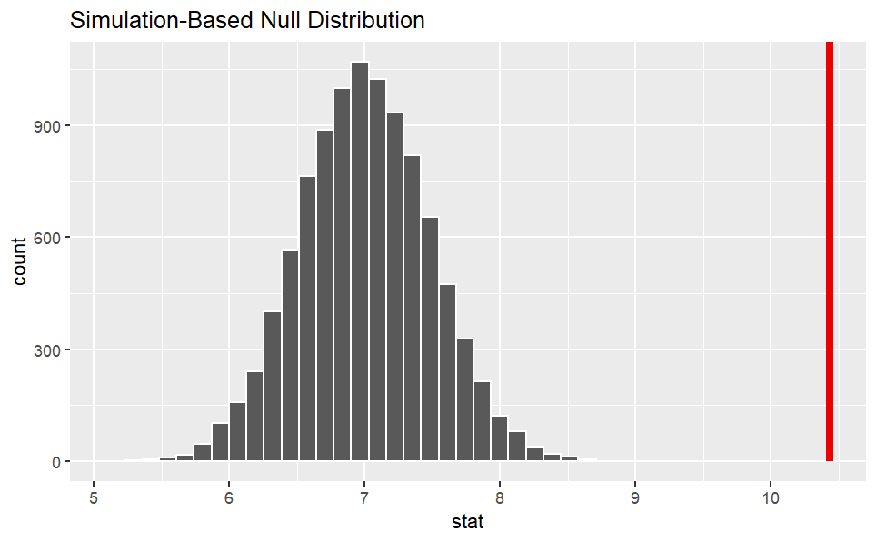

```r
sleep_null_distribution %>%
  visualise(bins = 30)+
  shade_p_value(obs_stat = observed_stat$mean_sleep_total, direction = "both")
```

### Step 5: Get p-value and interpret

```r
sleep_null_distribution %>%
  get_p_value(obs_stat = observed_stat$mean_sleep_total, direction = "both")
```

| p_value |
| --- |
| 0 |

The p-value is 0, and much lower than our signficance levels and therefore we can confidently reject the null hypothesis. This means that the average sleep total for the animals in this population is not 7 and therefore different from the average total sleep of jabberwockies.

## Question 3: Perform an appropriate statistical test to determine whether omnivores sleep for significantly longer than herbivores, on average.

### Step 1: generate hypothesis

compare two means ie two sample mean of independent groups H0: mean(ominvores) - mean(herbivores) = 0 H1 : mean(omivores)- mean(herbivores) = > 0 Significance level = 0.05 (i.e. happy to be wrong 1 in 20 times)

generate a null distrubution with random shuffle

### Step 2: Data exploration and wrangling

```r
omni_herbi_sleep <- msleep %>%
  select(vore, sleep_total) %>%
  filter(vore %in% c("omni", "herbi"))
```

```r
omni_herbi_sleep %>%
  count(vore)
```

| vore | n |
| --- | --- |
| herbi | 32 |
| omni | 20 |

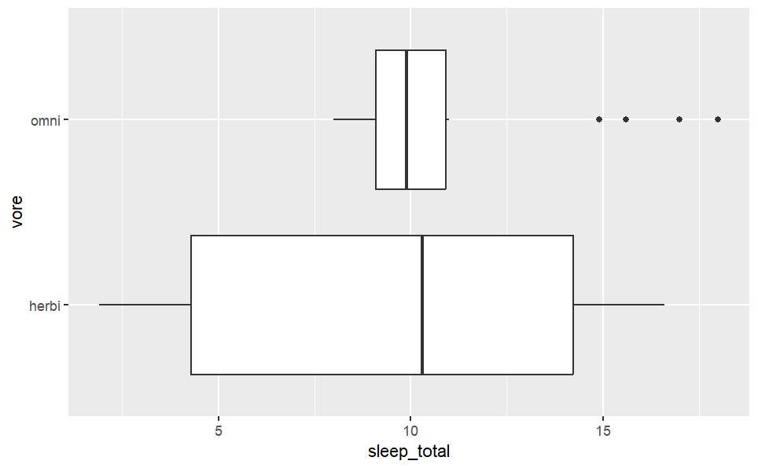

```r
omni_herbi_sleep %>%
  ggplot(aes(x = sleep_total, y = vore))+
  geom_boxplot()
```

### Step 2: Calculate test statistic

```r
obs_stat_omni_herb <- omni_herbi_sleep %>%
  specify(response =  sleep_total, explanatory = vore) %>%
  calculate(stat = "diff in means", order = c("omni", "herbi"))

obs_stat_omni_herb
```

```
Response: sleep_total (numeric)
Explanatory: vore (factor)
```

| stat |
| --- |
| 1.415625 |

### Step 3: Generate null distribution

```r
null_distribution_omni_herbi <- omni_herbi_sleep %>%
  specify(response = sleep_total, explanatory = vore) %>%
  hypothesise(null = "independence") %>%
  generate(reps = 1000, type = "permute") %>%
  calculate(stat = "diff in means", order = c("omni", "herbi"))
```

### Step 4: Visualise

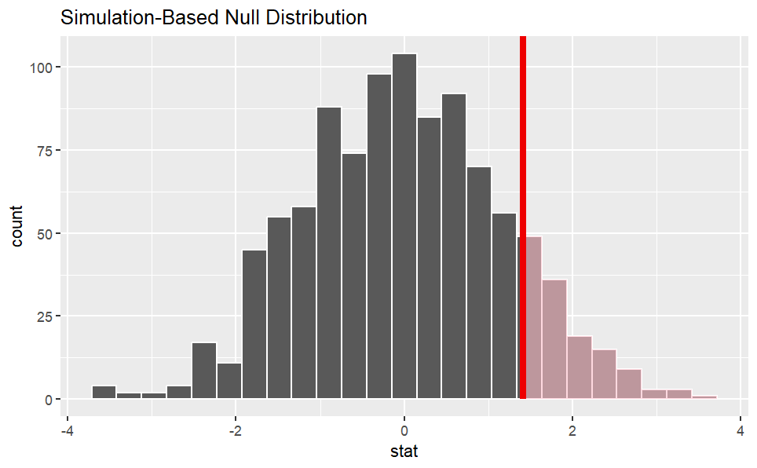

```r
null_distribution_omni_herbi %>%
  visualise(bins = 25)+
  shade_p_value(obs_stat = obs_stat_omni_herb$stat,
                direction = "greater")
```

### Step 5: Get p- value and interpret

```r
null_distribution_omni_herbi %>%
  get_p_value(obs_stat = obs_stat_omni_herb$stat,
                direction = "greater")
```

| p_value |
| --- |
| 0.12 |

The p-value is 0.119 and is higher than the signficance threshold (0.05) and therefore we have not disproved the null hypothesis. This means that omnivores do not sleep significantly longer than herbivores.

## Question 4: Question 4. Perform an appropriate statistical test to determine whether the proportion of domesticated animal types in the population of animal types is greater than 5%. Hint: Think about creating an is_domesticated variable for the analysis

### Step 1: generate hypotheses

One-sample proportion test, samples are independent

H0: proportion(domesticated_animals) = 5 H1: proportion(domesticated_animals) > 5 Significance level = 0.05

null distrubution will be draw, to test how often the domesticated animal ball is pulled from the sample bag.

### Step 2: Data exploration and wrangling

```r
msleep %>%
  distinct(name)
```

| name |
| --- |
| Cheetah |
| Owl monkey |
| Mountain beaver |
| Greater short-tailed shrew |
| Cow |
| Three-toed sloth |
| Northern fur seal |
| Vesper mouse |
| Dog |
| Roe deer |

[output cut: 73 more lines]

Label animals as domestic if they live alongside humans as companions or farm animals. Remove humans since domestic refers to animal’s ability to live alongside humans.

```r
domestic <- msleep %>%
  mutate(is_domesticated = if_else(name %in% c("Dog", "Cow", "Goat", "Horse", "Donkey", "Domestic cat", "Golden hamster", "Sheep", "Laboratory rat", "Pig"), "domesticated", "not_domesticated"), .after = name) %>%
  filter(name != "Human") %>%
  select(name, is_domesticated)
```

### Step 3: Calculate observed statistic (ie proportion domesticated animals)

```r
obs_stat <- domestic %>%
  filter(is_domesticated == "domesticated") %>%
  summarise(prop_dom = n() / nrow(domestic))

obs_stat
```

| prop_dom |
| --- |
| 0.1219512 |

### Step 4: Generate null distribution and visualise

```r
null_distribution_domestic <- domestic %>%
  specify(response = is_domesticated, success = "domesticated") %>%
  hypothesise(null = "point", p = 0.05) %>%
  generate(reps = 2000, type = "draw") %>%
  calculate(stat = "prop")
```

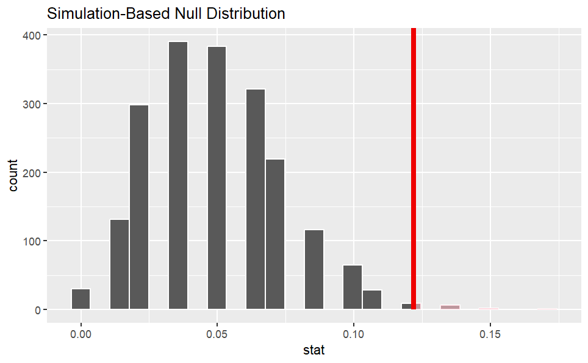

```r
null_distribution_domestic %>%
  visualise(bins = 25)+
  shade_p_value(obs_stat = obs_stat$prop_dom,
                direction = "greater")
```

### Step 5: Get p-value and interpret

```r
null_distribution_domestic %>%
  get_p_value(obs_stat = obs_stat$prop_dom,
                direction = "greater")
```

[output not shown]

The p value is 0.0085, which is lower than our defined significance level (0.05) and therefore we can reject the null hypothesis in favour of the H1. This means we can be confident that the proportion of domesticated animals in this population of animal types is higher than 5%